# PROJECT TITLE: Exploratory Data Analysis of COVID-19 Clinical Trials

## OBJECTIVES:

- to explore the dataset
- to gain insights into the characteristics of COVID-19 clinical trials, such as:

  - ```
    their status,
    ```

  - ```
    phases,
    ```

  - ```
    study designs and
    ```

  - ```
    demographics.
    ```

```python
## importing libraries
import pandas as pd
import numpy as np
import matplotlib.pyplot as plt
```

Loading dataset of covid-19 clinical trials downloaded as csv file from ClinicalTrials.gov database

```python
## loading dataset and renaming as covid_19_clinical_trials
covid_19_clinical_trials = pd.read_csv(r"C:\Users\DELL\Documents\Unified mentor project\covid-19_clinical_trial\COVID clinical trials.csv")
```

Exploratory data analysis Initial Data Exploration by exploring the basic structure and content of the dataset as thus...

```python
## viewing the first few rows of the dataset
print(covid_19_clinical_trials.head())
```

```
   Rank   NCT Number                                              Title  \
0     1  NCT04785898  Diagnostic Performance of the ID Now™ COVID-19...
1     2  NCT04595136  Study to Evaluate the Efficacy of COVID19-0001...
2     3  NCT04395482  Lung CT Scan Analysis of SARS-CoV2 Induced Lun...
3     4  NCT04416061  The Role of a Private Hospital in Hong Kong Am...
4     5  NCT04395924         Maternal-foetal Transmission of SARS-Cov-2

        Acronym                  Status         Study Results  \
0   COVID-IDNow  Active, not recruiting  No Results Available
1      COVID-19      Not yet recruiting  No Results Available
2   TAC-COVID19              Recruiting  No Results Available
3      COVID-19  Active, not recruiting  No Results Available
4  TMF-COVID-19              Recruiting  No Results Available

                                          Conditions  \
```

[output cut: 56 more lines]

```python
## checking the shape of the dataset
print(covid_19_clinical_trials.shape)
```

```
(5783, 27)
```

```python
## checking the columns in the dataset
print(covid_19_clinical_trials.columns)
```

```
Index(['Rank', 'NCT Number', 'Title', 'Acronym', 'Status', 'Study Results',
       'Conditions', 'Interventions', 'Outcome Measures',
       'Sponsor/Collaborators', 'Gender', 'Age', 'Phases', 'Enrollment',
       'Funded Bys', 'Study Type', 'Study Designs', 'Other IDs', 'Start Date',
       'Primary Completion Date', 'Completion Date', 'First Posted',
       'Results First Posted', 'Last Update Posted', 'Locations',
       'Study Documents', 'URL'],
      dtype='object')
```

```python
## checking the schema of each column
print(covid_19_clinical_trials.info())
```

```
<class 'pandas.core.frame.DataFrame'>
RangeIndex: 5783 entries, 0 to 5782
Data columns (total 27 columns):
 #   Column                   Non-Null Count  Dtype
---  ------                   --------------  -----
 0   Rank                     5783 non-null   int64
 1   NCT Number               5783 non-null   object
 2   Title                    5783 non-null   object
 3   Acronym                  2480 non-null   object
 4   Status                   5783 non-null   object
 5   Study Results            5783 non-null   object
 6   Conditions               5783 non-null   object
 7   Interventions            4897 non-null   object
 8   Outcome Measures         5748 non-null   object
 9   Sponsor/Collaborators    5783 non-null   object
```

[output cut: 20 more lines]

```python
## checking the summary statistics of the numerical columns (Rank & Enrollment)
print(covid_19_clinical_trials.describe())
```

```
              Rank    Enrollment
count  5783.000000  5.749000e+03
mean   2892.000000  1.831949e+04
std    1669.552635  4.045437e+05
min       1.000000  0.000000e+00
25%    1446.500000  6.000000e+01
50%    2892.000000  1.700000e+02
75%    4337.500000  5.600000e+02
max    5783.000000  2.000000e+07
```

```python
## now checking summary statistics for categorical columns
print(covid_19_clinical_trials.describe(include="object"))
```

```
         NCT Number                                              Title  \
count          5783                                               5783
unique         5783                                               5775
top     NCT04785898  Recombinant Human Angiotensin-converting Enzym...
freq              1                                                  2

         Acronym      Status         Study Results Conditions  \
count       2480        5783                  5783       5783
unique      2338          12                     2       3067
top     COVID-19  Recruiting  No Results Available   COVID-19
freq          47        2805                  5747        720

                 Interventions Outcome Measures  \
count                     4897             5748
unique                    4337             5687
top     Other: No intervention        Mortality
freq                        32                5

                          Sponsor/Collaborators Gender  ... Other IDs  \
count                                      5783   5773  ...      5782
unique                                     3631      3  ...      5734
top     Assistance Publique - Hôpitaux de Paris    All  ...  COVID-19
freq                                         78   5567  ...         6

         Start Date Primary Completion Date    Completion Date  \
count          5749                    5747               5747
unique          654                     877                978
top     May 1, 2020       December 31, 2020  December 31, 2021
freq            113                     122                179

          First Posted Results First Posted Last Update Posted  \
count             5783                   36               5783
unique             438                   33                269
top     April 24, 2020     November 4, 2020      April 8, 2021
freq               108                    2                109

                                 Locations  \
count                                 5198
unique                                4255
top     Uhmontpellier, Montpellier, France
freq                                    19

                                          Study Documents  \
count                                                 182
unique                                                182
top     "Statistical Analysis Plan", https://ClinicalT...
freq                                                    1

                                                URL
count                                          5783
unique                                         5783
top     https://ClinicalTrials.gov/show/NCT04785898
freq                                              1

[4 rows x 25 columns]
```

### Handling Missing Data

Checking for missing values and deciding how to handle them.

```python
#checking for missing values in each column
print(covid_19_clinical_trials.isnull().sum())
```

```
Rank                          0
NCT Number                    0
Title                         0
Acronym                    3303
Status                        0
Study Results                 0
Conditions                    0
Interventions               886
Outcome Measures             35
Sponsor/Collaborators         0
Gender                       10
Age                           0
Phases                     2461
Enrollment                   34
Funded Bys                    0
Study Type                    0
Study Designs                35
Other IDs                     1
Start Date                   34
Primary Completion Date      36
Completion Date              36
First Posted                  0
Results First Posted       5747
Last Update Posted            0
Locations                   585
Study Documents            5601
URL                           0
dtype: int64
```

By scanning, there is a high number of missing values in *acronym*, *interventions*, *phases*, *results first posted*, *locations* and *study documents* columns. now i will check the percentage of these missing values to decide on my next action.

```python
## Detecting percentage of missing values in each column
missing_percentage = covid_19_clinical_trials.isnull().mean() * 100
print(missing_percentage)
```

```
Rank                        0.000000
NCT Number                  0.000000
Title                       0.000000
Acronym                    57.115684
Status                      0.000000
Study Results               0.000000
Conditions                  0.000000
Interventions              15.320768
Outcome Measures            0.605222
Sponsor/Collaborators       0.000000
Gender                      0.172921
Age                         0.000000
Phases                     42.555767
Enrollment                  0.587930
Funded Bys                  0.000000
Study Type                  0.000000
Study Designs               0.605222
Other IDs                   0.017292
Start Date                  0.587930
Primary Completion Date     0.622514
Completion Date             0.622514
First Posted                0.000000
Results First Posted       99.377486
Last Update Posted          0.000000
Locations                  10.115857
Study Documents            96.852845
URL                         0.000000
dtype: float64
```

There is a high percentage of missing values in *acronym*, *phases*, *results first posted* and *study documents* columns. lets visualize this data to make a decision

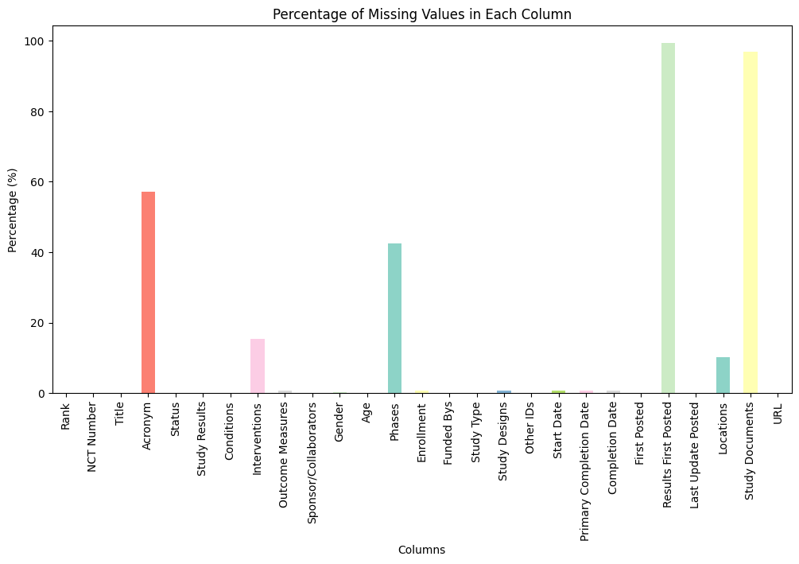

```python
## visualize the percentage of missing values using a bar plot
plt.figure(figsize=(12,6))
missing_percentage.plot(kind='bar')
plt.title('Percentage of Missing Values in Each Column')
plt.ylabel('Percentage (%)')
plt.xlabel('Columns')
colors = plt.cm.Set3.colors
bars = missing_percentage.plot(kind='bar', color=colors)
plt.show()
```

As visualized, the results in the *Results first posted* and *study documents* columns is 99.3% and 96.8% respectively. we will need to drop them as its impossible to input them without distroying our dataset.

```python
## dropping results first posted and study documents columns due to high missing values
covid_19_clinical_trials_cleaned = covid_19_clinical_trials.drop(columns=['Results First Posted', 'Study Documents'])
```

```python
## checking columns in dataframe after dropping
print(covid_19_clinical_trials_cleaned.columns)
```

```
Index(['Rank', 'NCT Number', 'Title', 'Acronym', 'Status', 'Study Results',
       'Conditions', 'Interventions', 'Outcome Measures',
       'Sponsor/Collaborators', 'Gender', 'Age', 'Phases', 'Enrollment',
       'Funded Bys', 'Study Type', 'Study Designs', 'Other IDs', 'Start Date',
       'Primary Completion Date', 'Completion Date', 'First Posted',
       'Last Update Posted', 'Locations', 'URL'],
      dtype='object')
```

now we check and drop duplicate rows

```python
## printing dataframe shape before dropping rows with duplicates
print("Shape before dropping duplicates:", covid_19_clinical_trials_cleaned.shape)
```

```
Shape before dropping duplicates: (5783, 25)
```

```python
##dropping duplicate rows
covid_19_clinical_trials_cleaned = covid_19_clinical_trials_cleaned.drop_duplicates()
```

```python
## now printing the shape after dropping duplicates
print("Shape after dropping duplicates:", covid_19_clinical_trials_cleaned.shape)
```

```
Shape after dropping duplicates: (5783, 25)
```

Judging by the shape before and after, its evident that there are no duplicates

Now lets extract a new column called *country* from the *location* column showing just the country where each study was conducted.

```python
## extracting countries from the 'Locations' column
Countries = covid_19_clinical_trials_cleaned['Locations'].str.split(',').str[-1].str.strip()
covid_19_clinical_trials_cleaned['Country'] = Countries
## checking if column is added
print(covid_19_clinical_trials_cleaned.columns)
print(covid_19_clinical_trials_cleaned['Country'].head())
```

```
Index(['Rank', 'NCT Number', 'Title', 'Acronym', 'Status', 'Study Results',
       'Conditions', 'Interventions', 'Outcome Measures',
       'Sponsor/Collaborators', 'Gender', 'Age', 'Phases', 'Enrollment',
       'Funded Bys', 'Study Type', 'Study Designs', 'Other IDs', 'Start Date',
       'Primary Completion Date', 'Completion Date', 'First Posted',
       'Last Update Posted', 'Locations', 'URL', 'Country'],
      dtype='object')
0        France
1      Colombia
2    San Marino
3     Hong Kong
4        France
Name: Country, dtype: object
```

Now We need to clasify the missing data to one of these categories

- Missing Completely At Random (MCAR)
- Missing At Random (MAR)
- Not Missing At Random (NMAR)

```python
# starting with acronym column -- printing value counts
print(f"Number of unique values is {covid_19_clinical_trials_cleaned.Acronym.nunique()} \n")
covid_19_clinical_trials_cleaned.Acronym.value_counts()
```

```
Number of unique values is 2338
```

```
Acronym
COVID-19         47
PROTECT           7
CORONA            6
SCOPE             5
RECOVER           5
                 ..
IgG4-COVID        1
Covid19-Pain      1
FACE COVID-19     1
SENTAD-COVID      1
US3R              1
Name: count, Length: 2338, dtype: int64
```

```python
#  Finding the relation between null values in Acronym and Countries columns
(covid_19_clinical_trials_cleaned.Acronym.isnull().groupby(covid_19_clinical_trials_cleaned.Country).mean().sort_values(ascending = False) * 100)[:60]
```

```
Country
Bahrain                   100.000000
Azerbaijan                100.000000
Cape Verde                100.000000
Cambodia                  100.000000
Bulgaria                  100.000000
Bosnia and Herzegovina    100.000000
Belarus                   100.000000
Guinea-Bissau             100.000000
Dominican Republic        100.000000
Ecuador                   100.000000
Iraq                      100.000000
Cyprus                    100.000000
South Sudan               100.000000
North Macedonia           100.000000
Kyrgyzstan                100.000000
Rwanda                    100.000000
Uruguay                   100.000000
Uzbekistan                100.000000
Republic of                96.774194
Taiwan                     93.750000
Singapore                  93.103448
Japan                      88.888889
Kuwait                     87.500000
China                      87.134503
Turkey                     86.757991
Ukraine                    85.714286
Malaysia                   84.615385
Egypt                      83.854167
Hungary                    83.333333
Hong Kong                  80.555556
Kazakhstan                 80.000000
India                      80.000000
Bangladesh                 80.000000
Saudi Arabia               77.777778
Puerto Rico                76.470588
Israel                     75.000000
Zimbabwe                   75.000000
Jordan                     72.727273
Poland                     72.413793
Indonesia                  71.428571
United States              69.376480
Romania                    69.230769
Kenya                      66.666667
Thailand                   66.666667
Slovakia                   66.666667
New Zealand                66.666667
Lebanon                    66.666667
Ethiopia                   66.666667
Nepal                      66.666667
Russian Federation         65.217391
Islamic Republic of        65.217391
Chile                      64.705882
Austria                    62.068966
Pakistan                   60.377358
Brazil                     59.124088
Mexico                     57.954545
Sweden                     57.894737
Argentina                  57.446809
Canada                     55.940594
Australia                  53.846154
Name: Acronym, dtype: float64
```

After finding the relation between the missing values in Acronym and Country columns, we can conclude that there is a sort of relation between these two, so we can say that Data is Missing At Random (MAR). Hence, we can Impute by Missing Category

```python
# filling null rows in acronym with 'missing acronym'
covid_19_clinical_trials_cleaned.Acronym = covid_19_clinical_trials_cleaned.Acronym.fillna('missing acronym')
```

```python
# now checking percentage of missing values in acronym column again
print(covid_19_clinical_trials_cleaned.isnull().mean() * 100)
# ok good. that column has no missing values now
```

```
Rank                        0.000000
NCT Number                  0.000000
Title                       0.000000
Acronym                     0.000000
Status                      0.000000
Study Results               0.000000
Conditions                  0.000000
Interventions              15.320768
Outcome Measures            0.605222
Sponsor/Collaborators       0.000000
Gender                      0.172921
Age                         0.000000
Phases                     42.555767
Enrollment                  0.587930
Funded Bys                  0.000000
Study Type                  0.000000
Study Designs               0.605222
Other IDs                   0.017292
Start Date                  0.587930
Primary Completion Date     0.622514
Completion Date             0.622514
First Posted                0.000000
Last Update Posted          0.000000
Locations                  10.115857
URL                         0.000000
Country                    10.115857
dtype: float64
```

Now doing the same for other categorical features such as Interventions , Phases ,Locations and other categorical features

```python
# Impute Interventions , Phases , Locations by Missing Category
categorical_features=covid_19_clinical_trials_cleaned.select_dtypes(include=['object']).columns
features=categorical_features[covid_19_clinical_trials_cleaned[categorical_features].isnull().mean()>0]
for feature in features:
    covid_19_clinical_trials_cleaned[feature]=covid_19_clinical_trials_cleaned[feature].fillna('Missing')
```

```python
# now detecting percentage of missing values again
print(covid_19_clinical_trials_cleaned.isnull().mean() * 100)
# good. now there are no missing values in any column except Enrollment column
```

```
Rank                       0.00000
NCT Number                 0.00000
Title                      0.00000
Acronym                    0.00000
Status                     0.00000
Study Results              0.00000
Conditions                 0.00000
Interventions              0.00000
Outcome Measures           0.00000
Sponsor/Collaborators      0.00000
Gender                     0.00000
Age                        0.00000
Phases                     0.00000
Enrollment                 0.58793
Funded Bys                 0.00000
Study Type                 0.00000
Study Designs              0.00000
Other IDs                  0.00000
Start Date                 0.00000
Primary Completion Date    0.00000
Completion Date            0.00000
First Posted               0.00000
Last Update Posted         0.00000
Locations                  0.00000
URL                        0.00000
Country                    0.00000
dtype: float64
```

Now handling missing data for enrollment column

```python
#checking the skewness of Enrollment column
print(covid_19_clinical_trials_cleaned['Enrollment'].skew())
```

```
34.06593382031148
```

The value of Skewness is 34 which means that we This feature isn't normally distributed

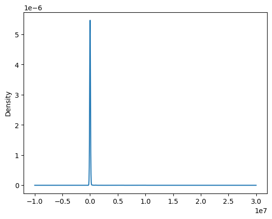

```python
# plotting the distribution of Enrollment column
covid_19_clinical_trials_cleaned['Enrollment'].plot(kind = 'kde')
```

so i will input the missing values by the median

```python
# computing median of Enrollment column
median_enrollment = covid_19_clinical_trials_cleaned['Enrollment'].median()

#filling missing values in Enrollment column with median value
covid_19_clinical_trials_cleaned['Enrollment'] = covid_19_clinical_trials_cleaned['Enrollment'].fillna(median_enrollment)
```

Having done this, now detecting percentage of missing data and printing cleaned dataframe

```python
# detecting percentage of missing values again
print(covid_19_clinical_trials_cleaned.isnull().mean() * 100)
```

```
Rank                       0.0
NCT Number                 0.0
Title                      0.0
Acronym                    0.0
Status                     0.0
Study Results              0.0
Conditions                 0.0
Interventions              0.0
Outcome Measures           0.0
Sponsor/Collaborators      0.0
Gender                     0.0
Age                        0.0
Phases                     0.0
Enrollment                 0.0
Funded Bys                 0.0
Study Type                 0.0
Study Designs              0.0
Other IDs                  0.0
Start Date                 0.0
Primary Completion Date    0.0
Completion Date            0.0
First Posted               0.0
Last Update Posted         0.0
Locations                  0.0
URL                        0.0
Country                    0.0
dtype: float64
```

```python
# since there are no missing values now, checking the data so we can proceed with further analysis
print(covid_19_clinical_trials_cleaned.head())
```

```
   Rank   NCT Number                                              Title  \
0     1  NCT04785898  Diagnostic Performance of the ID Now™ COVID-19...
1     2  NCT04595136  Study to Evaluate the Efficacy of COVID19-0001...
2     3  NCT04395482  Lung CT Scan Analysis of SARS-CoV2 Induced Lun...
3     4  NCT04416061  The Role of a Private Hospital in Hong Kong Am...
4     5  NCT04395924         Maternal-foetal Transmission of SARS-Cov-2

        Acronym                  Status         Study Results  \
0   COVID-IDNow  Active, not recruiting  No Results Available
1      COVID-19      Not yet recruiting  No Results Available
2   TAC-COVID19              Recruiting  No Results Available
3      COVID-19  Active, not recruiting  No Results Available
4  TMF-COVID-19              Recruiting  No Results Available

                                          Conditions  \
```

[output cut: 63 more lines]

```python
print(covid_19_clinical_trials_cleaned.info())
```

```
<class 'pandas.core.frame.DataFrame'>
RangeIndex: 5783 entries, 0 to 5782
Data columns (total 26 columns):
 #   Column                   Non-Null Count  Dtype
---  ------                   --------------  -----
 0   Rank                     5783 non-null   int64
 1   NCT Number               5783 non-null   object
 2   Title                    5783 non-null   object
 3   Acronym                  5783 non-null   object
 4   Status                   5783 non-null   object
 5   Study Results            5783 non-null   object
 6   Conditions               5783 non-null   object
 7   Interventions            5783 non-null   object
 8   Outcome Measures         5783 non-null   object
 9   Sponsor/Collaborators    5783 non-null   object
```

[output cut: 19 more lines]

Proceeding to data visualization of the following:

- countries with highest number of clinical trials
- status of the trials
- gender and
- month with the highest start

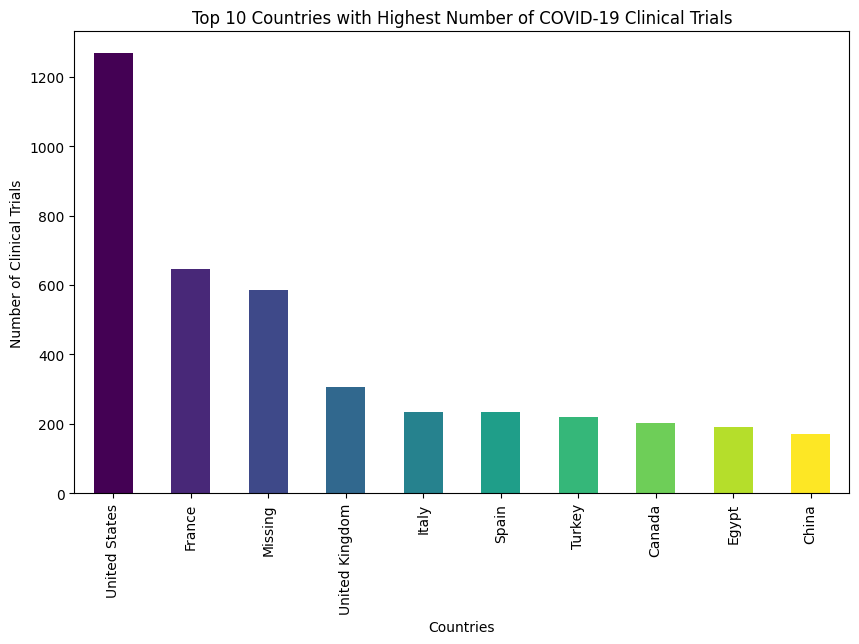

```python
# visualizing countries with the highest number of clinical trials
top_10_countries = covid_19_clinical_trials_cleaned['Country'].value_counts().head(10)
n=len(top_10_countries)
colors = plt.cm.viridis(np.linspace(0, 1, n))
plt.figure(figsize=(10,6))
top_10_countries.plot(kind='bar', color=colors)
plt.title('Top 10 Countries with Highest Number of COVID-19 Clinical Trials')
plt.ylabel('Number of Clinical Trials')
plt.xlabel('Countries')
plt.show()
```

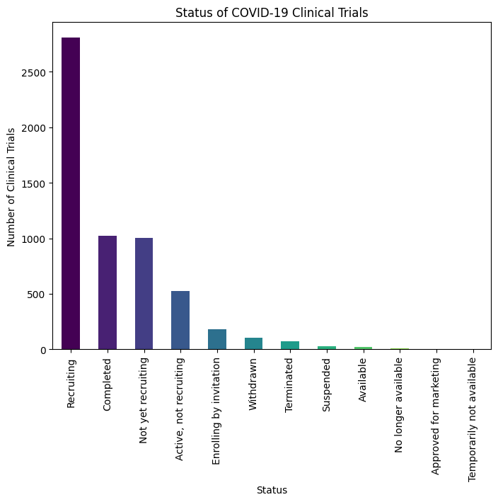

```python
# visualizing status of clinical trials
status_counts = covid_19_clinical_trials_cleaned['Status'].value_counts()
colors = plt.cm.viridis(np.linspace(0, 1, n))
plt.figure(figsize=(8,6))
status_counts.plot(kind='bar', color=colors)
plt.title('Status of COVID-19 Clinical Trials')
plt.ylabel('Number of Clinical Trials')
plt.xlabel('Status')
plt.show()
```

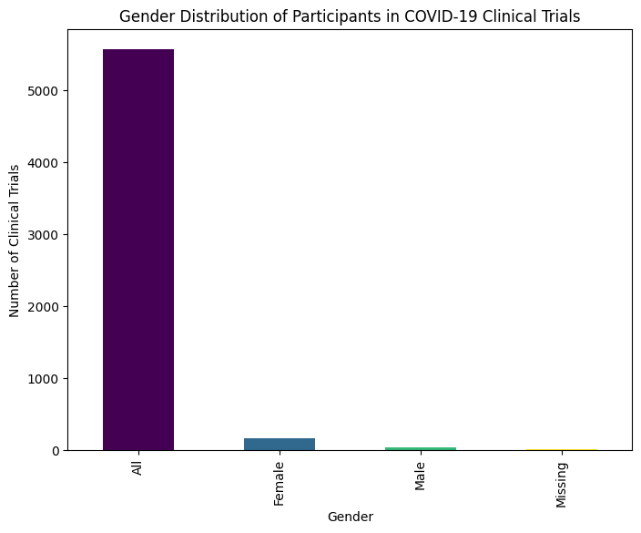

```python
# visualizing gender distribution of participants in the clinical trial
gender_counts = covid_19_clinical_trials_cleaned['Gender'].value_counts()
n=len(gender_counts)
colors = plt.cm.viridis(np.linspace(0, 1, n))
plt.figure(figsize=(8,6))
gender_counts.plot(kind='bar', color=colors)
plt.title('Gender Distribution of Participants in COVID-19 Clinical Trials')
plt.ylabel('Number of Clinical Trials')
plt.xlabel('Gender')
plt.show()
```

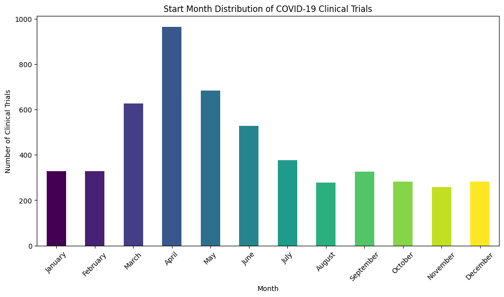

```python
# visualizing month as names arranged chronologically with the highest start of clinical trials from the start date
covid_19_clinical_trials_cleaned['Start Date'] = pd.to_datetime(covid_19_clinical_trials_cleaned['Start Date'], errors='coerce')
covid_19_clinical_trials_cleaned['Start Month'] = covid_19_clinical_trials_cleaned['Start Date'].dt.month_name()
start_month_counts = covid_19_clinical_trials_cleaned['Start Month'].value_counts()
months_order = [
    'January', 'February', 'March', 'April', 'May', 'June',
    'July', 'August', 'September', 'October', 'November', 'December'
]

start_month_counts = start_month_counts.reindex(months_order)

n = len(months_order)
colors = plt.cm.viridis(np.linspace(0, 1, n))

plt.figure(figsize=(12, 6))
start_month_counts.plot(kind='bar', color=colors)

plt.title('Start Month Distribution of COVID-19 Clinical Trials')
plt.ylabel('Number of Clinical Trials')
plt.xlabel('Month')
plt.xticks(rotation=45)
plt.show()
```